# 2.4 Position

## Measures of Position

The **interquartile range** (**IQR**) represents the middle 50% of the data.

- This is another measure of variability!

## Percentiles

- Recall that the *median* cut the data in half: 50% of the data is below and 50% is above the median.
- This is also called the **50th percentile**.
- The **\(p\)th percentile** is the value for which \(p\)% of the data is below it.

To get the middle 50%, we will split the data into four parts:

| 1 | 2 | 3 | 4 |
| --- | --- | --- | --- |
| 25% | 25% | 25% | 25% |

The 25th and 75th percentiles, along with the median, divide the data into four parts.

## Quartiles

We call these three measurements the **quartiles**:

- **Q1**, the first quartile, is the median of the lower 50% of the data.
- **Q2**, the second quartile, is the median.
- **Q3**, the third quartile, is the median of the upper 50% of the data.

## Example

Consider {1, 2, 3, 4, 5, 6, 7, 8, 9, 10}

- Cutting the data in half: {1, 2, 3, 4, 5 | 6, 7, 8, 9, 10}
- So the median (Q2) is \(\frac{5+6}{2}=5.5\).
- Q1 is the median of {1, 2, 3, 4, 5}, or 3
- Q3 is the median of {6, 7, 8, 9, 10}, or 8

**Note:** this is a “quick and dirty” way of finding quartiles. A computer will give a more exact result.

## Interquartile Range

Then the interquartile range is \[ \text{IQR} = \text{Q3}-\text{Q1} \]

- The IQR is resistant to extreme values.

## Which measure to use?

- mean and standard deviation when the data are symmetric
- median and IQR when the data are skewed

## Box Plots

Box plots summarize the data with 5 statistics plus extreme observations:

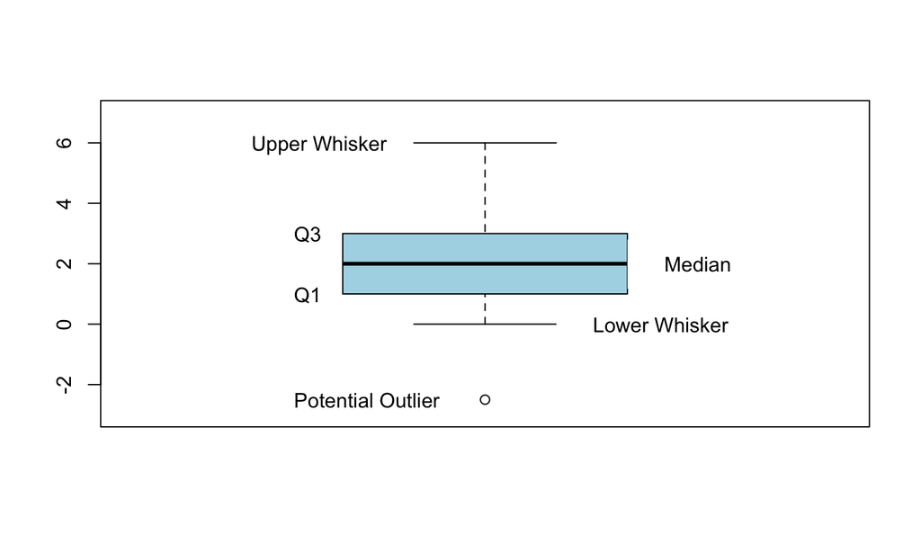

## Drawing a box plot:

1. Draw the vertical axis to include all possible values in the data.
2. Draw a horizontal line at the median, at \(\text{Q1}\), and at \(\text{Q3}\). Use these to form a box.
3. Draw the **whiskers**. The whiskers’ upper limit is \(\text{Q3}+1.5\times\text{IQR}\) and the lower limit is \(\text{Q1}-1.5\times\text{IQR}\). The actual whiskers are then drawn *at the next closest data points within the limits*.
4. Any points outside the whisker limits are included as individual points. These are **potential outliers**.

We won’t draw box plots by hand, but understanding how they are drawn will help us understand how to interpret them!

## Outliers

(Potential) outliers can help us…

- examine skew (outliers in the negative direction suggest left skew; outliers in the positive direction suggest right skew).
- identify issues with data collection or entry, especially if the value of the outliers doesn’t make sense.

## Descriptive Measures for Populations

- We’ve thought about calculating various descriptive statistics from a sample.
- Our long-term goal is to estimate descriptive information about a population.
- At the population level, these values are called **parameters**.
- When we find a measure of center, spread, or position, we use a sample to calculate a single value.
- These single values are called **point estimates**.
  - They are used to *estimate* the corresponding population parameter.

| Point Estimate | Parameter |
| --- | --- |
| sample mean: \(\bar{x}\) | population mean: \(\mu\) |
| sample standard deviation: \(s\) | population standard deviation: \(\sigma\) |